## Introduction

This is a sample R solution to “Assignment 2 - Sea Level rise in Santa Barbara”, as presented in Spring 2021.

The R solution was originally prepared by Bren PhD student [Linus Blomqvist](https://bren.ucsb.edu/people/linus-blomqvist), who took 263 on the condition that he could do the work in R…

This version of the solution has been tweaked and instructionalized by Frew (so if it breaks, don’t blame Linus.)

## Loading and exploring data

Download and uznip [`data_hw2.zip`](https://frew.eri.ucsb.edu/private/EDS223/data_hw2.zip).

What layers are in `basemap.gpkg`?

```r
# view layers in GeoPackage basemap

st_layers("data_hw2/basemap.gpkg")
```

```
## Driver: GPKG
## Available layers:
##   layer_name     geometry_type features fields
## 1 California     Multi Polygon      179     14
## 2     Cities     Multi Polygon        8      6
## 3     County     Multi Polygon        1      6
## 4        ROI     Multi Polygon        1      4
## 5    Streets Multi Line String    20745     75
```

> Note: Except for the `ROI` layer, the layers in `basemap.gpkg` are of historical interest only, for use in GIS/programming environments that don’t already provide decent base maps.

Read them in:

```r
# read in simple feature (sf) GeoPackages

california <- read_sf("data_hw2/basemap.gpkg", layer = "California")
cities     <- read_sf("data_hw2/basemap.gpkg", layer = "Cities")
county     <- read_sf("data_hw2/basemap.gpkg", layer = "County")
ROI        <- read_sf("data_hw2/basemap.gpkg", layer = "ROI")
streets    <- read_sf("data_hw2/basemap.gpkg", layer = "streets")
```

What are the attributes of the `california` layer?

```r
names(california)
```

```
##  [1] "OBJECTID"     "NAME_PCASE"   "NAME_UCASE"   "FMNAME_PC"    "FMNAME_UC"
##  [6] "ABBREV"       "NUM"          "ABCODE"       "FIPS"         "ANSI"
## [11] "ISLAND"       "Shape_Leng"   "Shape_Length" "Shape_Area"   "geom"
```

What does the `california` layer look like?

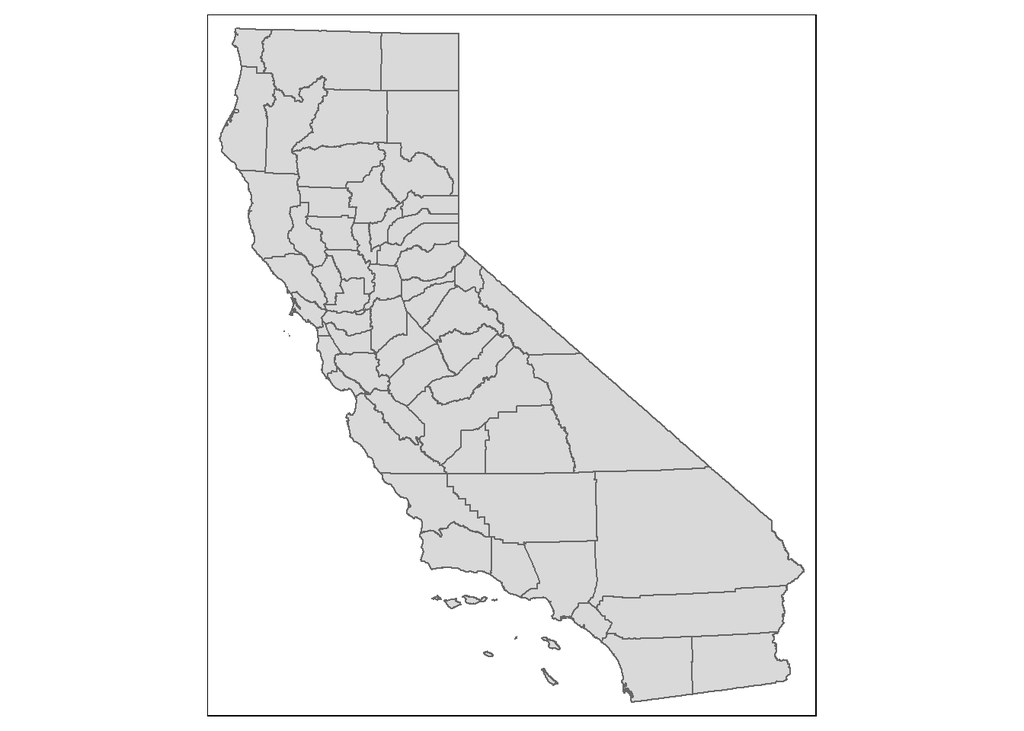

```r
tm_shape(st_geometry(california)) +
  tm_polygons()
```

Looks like county polygons. (Sure took a while to plot—any ideas why?)

Check out the `ROI` layer. We’ll use `"view"` mode to display it on a live base map, so we have some local detail to orient ourselves with:

```r
tmap_mode("view")
tm_shape(ROI) +
  tm_borders()
```

[interactive chart not shown]

What layers are in `parcels.gpkg`?

```r
st_layers("data_hw2/parcels.gpkg")
```

```
## Driver: GPKG
## Available layers:
##   layer_name geometry_type features fields
## 1    parcels       Polygon     6537     54
```

There’s only one, so you don’t need to specify it when you read it in:

```r
parcels <- read_sf("data_hw2/parcels.gpkg")
```

We’re interested in the `NET_AV` attribute. Let’s plot it:

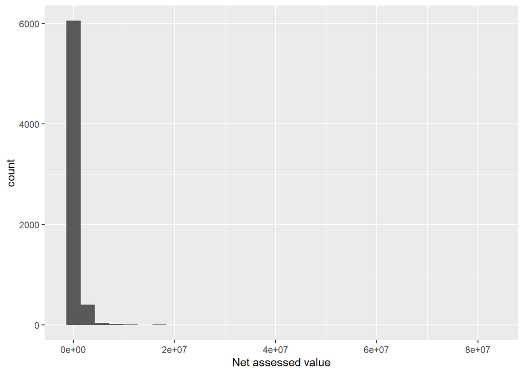

```r
ggplot(parcels) +
  geom_histogram(aes(x = NET_AV)) +
  xlab("Net assessed value")
```

Yikes, there are a lot more small values than large ones. Let’s look at the log of `NET_AV` instead:

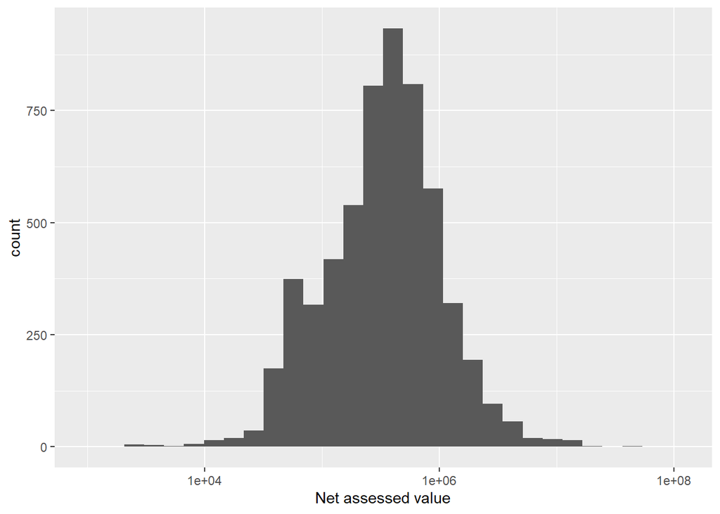

```r
# property values are log normally distributed

ggplot(parcels) +
  geom_histogram(aes(x = NET_AV)) +
  scale_x_log10() +
  xlab("Net assessed value")
```

For the inundation scenarios, combine all the layers into a single `sf` object.

```r
# Get layer names
#
inund_layers <- st_layers("data_hw2/inundation_scenarios.gpkg")$name

# Start with one layer and then row bind the others onto it with a loop
#
scenarios <- read_sf("data_hw2/inundation_scenarios.gpkg", layer = inund_layers[1])

for(i in 2:length(inund_layers)) {
  scenarios <- rbind(scenarios,
                     read_sf("data_hw2/inundation_scenarios.gpkg", layer = inund_layers[i]))
}
```

Let’s look at one of these scenarios:

```r
tm_shape(filter(scenarios, GRIDCODE == 10)) +
  tm_fill(col = "lightblue") +
  tm_shape(ROI) +
  tm_borders()
```

[interactive chart not shown]

Looks like this represents current land area that would be inundated under the scenario in question.

## Spatial join

Find the total value of all parcels that fall within the inundated area for each scenario.

```r
# we calculate the area of each parcel,
# just in case the existing Shape_Area attribute hasn't been kept up-to-date
#
parcels$area <- st_area(parcels)

# convert calculated areas (which will be in CRS units) to hectares
#
units(parcels$area) <- make_units(ha)

# join the scenarios to the the parcels
# and calculate total assessed value, total area, and number of parcels
# inundated by each SLR scenario
#
scenarios <- scenarios %>%
  st_join(parcels, join = st_intersects) %>%
  group_by(GRIDCODE) %>%
  summarize(parcel_count = n(),
            net_value = round(sum(NET_AV)/1e6, 0),
            area = round(sum(area), 0))
```

## Results: table

Clean up `scenarios`:

```r
# rename GRIDCODE column
#
names(scenarios)[1] <- "scenario"

# display as table, without geometry
#
table <- st_drop_geometry(scenarios)
gt(table)
```

| scenario | parcel_count | net_value | area |
| --- | --- | --- | --- |
| 1 | 60 | 51 | 43 [ha] |
| 2 | 89 | 88 | 108 [ha] |
| 3 | 227 | 195 | 189 [ha] |
| 4 | 620 | 566 | 301 [ha] |
| 5 | 1275 | 909 | 354 [ha] |
| 6 | 1863 | 1215 | 392 [ha] |
| 7 | 2196 | 1372 | 436 [ha] |
| 8 | 2614 | 1555 | 465 [ha] |
| 9 | 2958 | 1712 | 486 [ha] |
| 10 | 3287 | 1881 | 512 [ha] |

Optional: extra-bitchin formatting:

```r
library(kableExtra)
st_drop_geometry(scenarios) %>%
  kbl(col.names = c("Sea-level rise (m)",
                    "Parcel count",
                    "Net loss ($m)",
                    "Area flooded (ha)")) %>%
  kable_material(c("striped", "hover"))
```

| Sea-level rise (m) | Parcel count | Net loss ($m) | Area flooded (ha) |
| --- | --- | --- | --- |
| 1 | 60 | 51 | 43 [ha] |
| 2 | 89 | 88 | 108 [ha] |
| 3 | 227 | 195 | 189 [ha] |
| 4 | 620 | 566 | 301 [ha] |
| 5 | 1275 | 909 | 354 [ha] |
| 6 | 1863 | 1215 | 392 [ha] |
| 7 | 2196 | 1372 | 436 [ha] |
| 8 | 2614 | 1555 | 465 [ha] |
| 9 | 2958 | 1712 | 486 [ha] |
| 10 | 3287 | 1881 | 512 [ha] |

## Results: map

In the map, the numbers 1 through 10 represent the number of meters of sea-level rise associated with each scenario and the intensity of the color represents the amount of property value lost.

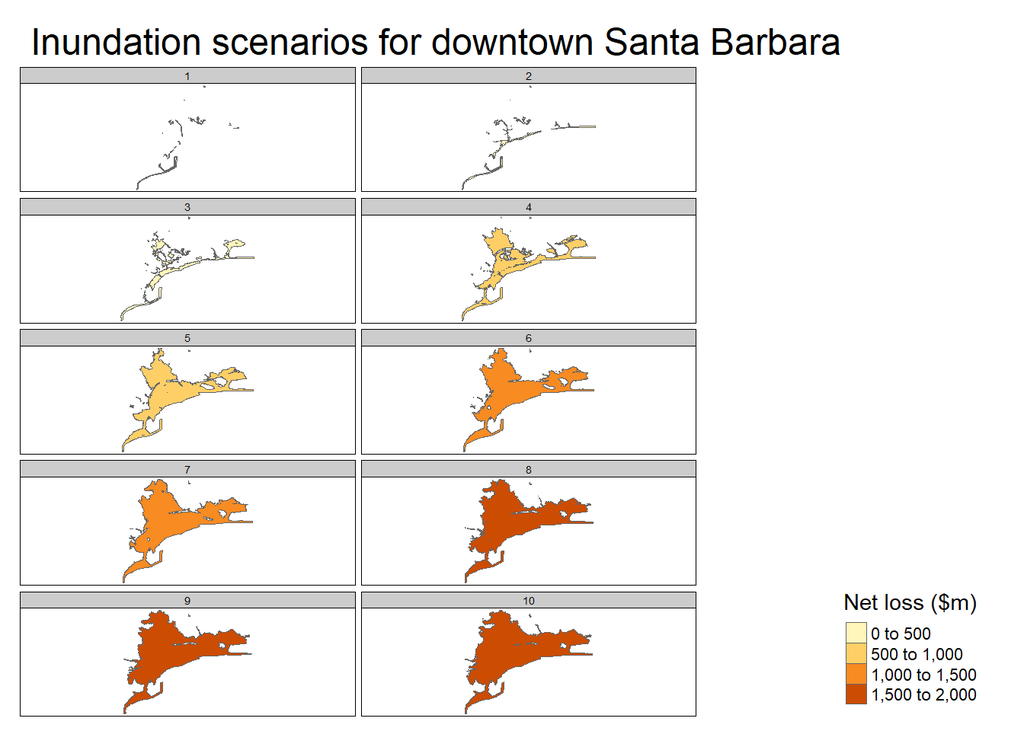

```r
tmap_mode("plot")
tm_shape(scenarios) +
  tm_polygons("net_value", title = "Net loss ($m)") +
  tm_facets(by = "scenario", nrow = 5, ncol = 2) +
  tm_layout(main.title = "Inundation scenarios for downtown Santa Barbara",
            legend.position = c("right", "bottom"))
```

Just for s&g, let’s do an interactive map:

```r
map_layer <- function(scenarios, depth) {
  tm_shape(filter(scenarios, scenario == depth), name = sprintf("%d m", depth)) +
    tm_fill(col = "blue", alpha = 0.5)
}

map = map_layer(scenarios, 10)
for (i in 9:1) {
  map = map + map_layer(scenarios, i)
}

tmap_mode("view")
```

```
## tmap mode set to interactive viewing
```

```r
map
```

[interactive chart not shown]